# Data Analysis Nanodegree program project

# A deep analysis into a TMDB database to gain Movie Insights

- Introduction
- Data Wrangling
- Exploratory Data Analysis
- Conclusions

## Introduction

> **Tip**: In this Data Analysis project, I would be investigating a TMDB movies database file which has a collection of important details of about 10,000 movies listed on TMDB.

This will enable me advise a client who intends to go into movie production on the most popular movie genres, Best director to get the Job done, Average Budget, typical runtime and Possible Revenue expectations

### Questions to be Answered

1. General questions about the dataset.
1. Which movie had the greatest and least runtime?
2. Which movie had the greatest and least budget?
3. Which movie had the greatest and least revenue?
4. What is the average runtime of all movies?
5. Average Budget.
6. Average revenue.
7. Which director directed most films?
8. Which genre were more successful?

```python
import pandas as pd

#reading tmdb csv file and storing that to a variable
movies_tmdb = pd.read_csv('tmdb_movies_data.csv')

#calling out first 5 rows (excluding headers) of tmdb database
movies_tmdb.head()
```

### What can we say about the dataset provided?

```python
movies_tmdb.shape
```

```python
movies_tmdb.describe()
```

|  | id | popularity | budget | revenue | runtime | vote_count | vote_average | release_year | budget_adj | revenue_adj |
| --- | --- | --- | --- | --- | --- | --- | --- | --- | --- | --- |
| count | 10866.000000 | 10866.000000 | 1.086600e+04 | 1.086600e+04 | 10866.000000 | 10866.000000 | 10866.000000 | 10866.000000 | 1.086600e+04 | 1.086600e+04 |
| mean | 66064.177434 | 0.646441 | 1.462570e+07 | 3.982332e+07 | 102.070863 | 217.389748 | 5.974922 | 2001.322658 | 1.755104e+07 | 5.136436e+07 |
| std | 92130.136561 | 1.000185 | 3.091321e+07 | 1.170035e+08 | 31.381405 | 575.619058 | 0.935142 | 12.812941 | 3.430616e+07 | 1.446325e+08 |
| min | 5.000000 | 0.000065 | 0.000000e+00 | 0.000000e+00 | 0.000000 | 10.000000 | 1.500000 | 1960.000000 | 0.000000e+00 | 0.000000e+00 |
| 25% | 10596.250000 | 0.207583 | 0.000000e+00 | 0.000000e+00 | 90.000000 | 17.000000 | 5.400000 | 1995.000000 | 0.000000e+00 | 0.000000e+00 |
| 50% | 20669.000000 | 0.383856 | 0.000000e+00 | 0.000000e+00 | 99.000000 | 38.000000 | 6.000000 | 2006.000000 | 0.000000e+00 | 0.000000e+00 |
| 75% | 75610.000000 | 0.713817 | 1.500000e+07 | 2.400000e+07 | 111.000000 | 145.750000 | 6.600000 | 2011.000000 | 2.085325e+07 | 3.369710e+07 |
| max | 417859.000000 | 32.985763 | 4.250000e+08 | 2.781506e+09 | 900.000000 | 9767.000000 | 9.200000 | 2015.000000 | 4.250000e+08 | 2.827124e+09 |

```python
movies_tmdb.info()
```

```
<class 'pandas.core.frame.DataFrame'>
RangeIndex: 10866 entries, 0 to 10865
Data columns (total 21 columns):
id                      10866 non-null int64
imdb_id                 10856 non-null object
popularity              10866 non-null float64
budget                  10866 non-null int64
revenue                 10866 non-null int64
original_title          10866 non-null object
cast                    10790 non-null object
homepage                2936 non-null object
director                10822 non-null object
tagline                 8042 non-null object
keywords                9373 non-null object
overview                10862 non-null object
runtime                 10866 non-null int64
genres                  10843 non-null object
production_companies    9836 non-null object
release_date            10866 non-null object
vote_count              10866 non-null int64
vote_average            10866 non-null float64
release_year            10866 non-null int64
budget_adj              10866 non-null float64
revenue_adj             10866 non-null float64
dtypes: float64(4), int64(6), object(11)
memory usage: 1.7+ MB
```

### Data Cleaning & Wrangling (Removing the unused information from the dataset )

> **Important observation regarding this process**
> 1. We need to remove unused column such as id, imdb_id, vote_count, production_company, keywords, homepage etc.
> 2. We also need to remove duplicate rows(if any).
> 3. Some movies in the database have zero budget or zero revenue as such we need to discard them
> 4. Replacing zero with NAN in runtime column.
> 5. We need to change the release within the date column into a date format.
> 6. Changing format of budget and revenue column.

```python
#importing all the nescessory libraries we need for our analysis
import numpy as np
from matplotlib import pyplot as plt
import seaborn as sns

#this variable will store the database of tmdb movies into a dataframe
movies_data = pd.read_csv('tmdb_movies_data.csv')
```

It will be great to check the size of our database set now

```python
rows, col = movies_data.shape
print('We have {} total entries of movies and {} different column containing it.'.format(rows-1, col))
```

```
We have 10865 total entries of movies and 21 different column containing it.
```

It is important to remove any duplicate data within the columns

```python
#lets give a list of movies that needs to be deleted
del_col = [ 'id', 'imdb_id', 'popularity', 'budget_adj', 'revenue_adj', 'homepage', 'keywords', 'overview', 'production_companies', 'vote_count', 'vote_average']


#deleting the columns from the database
movies_data = movies_data.drop(del_col, 1)
#now take a look at this new dataset
movies_data.head(3)
```

|  | budget | revenue | original_title | cast | director | tagline | runtime | genres | release_date | release_year |
| --- | --- | --- | --- | --- | --- | --- | --- | --- | --- | --- |
| 0 | 150000000 | 1513528810 | Jurassic World | Chris Pratt\|Bryce Dallas Howard\|Irrfan Khan\|Vi... | Colin Trevorrow | The park is open. | 124 | Action\|Adventure\|Science Fiction\|Thriller | 6/9/2015 | 2015 |
| 1 | 150000000 | 378436354 | Mad Max: Fury Road | Tom Hardy\|Charlize Theron\|Hugh Keays-Byrne\|Nic... | George Miller | What a Lovely Day. | 120 | Action\|Adventure\|Science Fiction\|Thriller | 5/13/2015 | 2015 |
| 2 | 110000000 | 295238201 | Insurgent | Shailene Woodley\|Theo James\|Kate Winslet\|Ansel... | Robert Schwentke | One Choice Can Destroy You | 119 | Adventure\|Science Fiction\|Thriller | 3/18/2015 | 2015 |

The difference between the database and now is the data is alot more compact now and easier to analyze

It is important to remove any duplicate data withi the row

```python
#will drop duplicate rows but will keep the first one
movies_data.drop_duplicates(keep = 'first', inplace = True)

rows, col = movies_data.shape
print('We now have {} total entries of movies and {} columns/features of it.'.format(rows-1, col))
```

```
We now have 10864 total entries of movies and 10 columns/features of it.
```

So we had one duplicate copy of a movie. Now we have 10864 movie entries.

**Now, lets figure out which movies have a value of `'0'` in their `budget` or `revenue`, and then deleting those movies from database.**

```python
#giving alist of column names that needs to be checked
check_row = ['budget', 'revenue']

#this will replace the value of '0' to NaN of columns given in the list
movies_data[check_row] = movies_data[check_row].replace(0, np.NaN)

#now we will drop any row which has NaN values in any of the column of the list (check_row)
movies_data.dropna(subset = check_row, inplace = True)

rows, col = movies_data.shape
print('After cleaning, we now have only {} entries of movies.'.format(rows-1))
```

```
After cleaning, we now have only 3853 entries of movies.
```

As you saw in the previous dataset from having 10,000 rows and 21 columns we have now come down to 3853 rows and 10 columns. These many columns are needed for analysis and we have all the rows that have valid values for our calculations.

Now as we are done with cleaning the dataset, let's move on to data wrangling phase.

## Data Wrangling

**Now first lets check if we have any movie with a runtime value of `0`. If we have any, we will replace with `NaN`.**

```python
#replacing 0 with NaN of runtime column of the dataframe
movies_data['runtime'] = movies_data['runtime'].replace(0, np.NaN)
```

**Now we need to convert the `'release_date'` column to date format**

```python
#calling the column which need to be formatted in datetime and storing those values in them
movies_data.release_date = pd.to_datetime(movies_data['release_date'])

#showing the dataset
movies_data.head(2)
```

|  | budget | revenue | original_title | cast | director | tagline | runtime | genres | release_date | release_year |
| --- | --- | --- | --- | --- | --- | --- | --- | --- | --- | --- |
| 0 | 150000000.0 | 1.513529e+09 | Jurassic World | Chris Pratt\|Bryce Dallas Howard\|Irrfan Khan\|Vi... | Colin Trevorrow | The park is open. | 124 | Action\|Adventure\|Science Fiction\|Thriller | 2015-06-09 | 2015 |
| 1 | 150000000.0 | 3.784364e+08 | Mad Max: Fury Road | Tom Hardy\|Charlize Theron\|Hugh Keays-Byrne\|Nic... | George Miller | What a Lovely Day. | 120 | Action\|Adventure\|Science Fiction\|Thriller | 2015-05-13 | 2015 |

As you see, the `'release_date'` column has been changed to date format. (year-month-day)

**Lets see if all the columns are in the format that we want for our calculations.**

```python
#showing the datatypes of all the columns
movies_data.dtypes
```

```
budget                   float64
revenue                  float64
original_title            object
cast                      object
director                  object
tagline                   object
runtime                    int64
genres                    object
release_date      datetime64[ns]
release_year               int64
dtype: object
```

As we can see we have float values for `'budget'` and `'revenue'` columns, since we dont need float but in integers within our dataset, lets convert them for easier calculation

```python
#applymap function changes the columns data type to the type 'argument' we pass
change_coltype = ['budget', 'revenue']

movies_data[change_coltype] = movies_data[change_coltype].applymap(np.int64)
#showing the datatypes of all columns
movies_data.dtypes
```

```
budget                     int64
revenue                    int64
original_title            object
cast                      object
director                  object
tagline                   object
runtime                    int64
genres                    object
release_date      datetime64[ns]
release_year               int64
dtype: object
```

Now all columns are in the desired format.

`'Buget'`& `'Revenue'` are better as integers as such we will be converting them from floats to integers while also assigning a currency to them

```python
#rename function renames the columns, the key as being the old name and its value new name of it in form of dictionary.
movies_data.rename(columns = {'budget' : 'budget_(in_NGN_Naira)', 'revenue' : 'revenue_(in_NGN_Naira)'}, inplace = True)
```

## Exploratory Data Analysis

Within this section, we would be exploring the data for insights

The Histograms below shows data overview of the entire data set

```
array([[<matplotlib.axes._subplots.AxesSubplot object at 0x1a16f07518>,
      dtype=object)
```

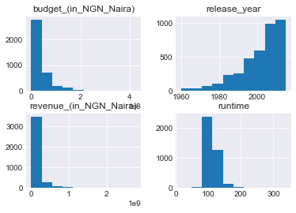

```python
movies_data.hist()
```

# Check Movie Runtime,Budget,Revenue, Best Director, Best Genre**

Within this Section we will be answering the following questions

1. General questions about the dataset.
1. Which movie had the greatest and least runtime?
2. Which movie had the greatest and least budget?
3. Which movie had the greatest and least revenue?
4. What is the average runtime of all movies?
5. Average Budget.
6. Average revenue.
7. Which director directed most films?
8. Which genre were more successful?

### 1A

#### Which movie had the greatest and least runtime?

```python
#To get the runtime, we would use a new set of values

highest_lowest('runtime')
```

|  | 2107 | 5162 |
| --- | --- | --- |
| budget_(in_NGN_Naira) | 18000000 | 10 |
| revenue_(in_NGN_Naira) | 871279 | 5 |
| original_title | Carlos | Kid's Story |
| cast | Edgar RamÃrez\|Alexander Scheer\|Fadi Abi Samra... | Clayton Watson\|Keanu Reeves\|Carrie-Anne Moss\|K... |
| director | Olivier Assayas | Shinichiro Watanabe |
| tagline | The man who hijacked the world | NaN |
| runtime | 338 | 15 |
| genres | Crime\|Drama\|Thriller\|History | Science Fiction\|Animation |
| release_date | 2010-05-19 00:00:00 | 2003-06-02 00:00:00 |
| release_year | 2010 | 2003 |

Looking at the data above and their Runtimes, it is interesting to note that the movie `Carlos`, had the highest runtime of 338min!

while the movie`Kid's story`, had the shortest runtime of just 15 mins!

### 1B

#### Which movie had the greatest and least budget?

```python
#as our calculations seems to be same as previous one for different column, lets call the function by passing desired argument

highest_lowest('budget_(in_NGN_Naira)')
```

|  | 2244 | 2618 |
| --- | --- | --- |
| budget_(in_NGN_Naira) | 425000000 | 1 |
| revenue_(in_NGN_Naira) | 11087569 | 100 |
| original_title | The Warrior's Way | Lost & Found |
| cast | Kate Bosworth\|Jang Dong-gun\|Geoffrey Rush\|Dann... | David Spade\|Sophie Marceau\|Ever Carradine\|Step... |
| director | Sngmoo Lee | Jeff Pollack |
| tagline | Assassin. Hero. Legend. | A comedy about a guy who would do anything to ... |
| runtime | 100 | 95 |
| genres | Adventure\|Fantasy\|Action\|Western\|Thriller | Comedy\|Romance |
| release_date | 2010-12-02 00:00:00 | 1999-04-23 00:00:00 |
| release_year | 2010 | 1999 |

This dats shows us that the movie `The Warriors Way` had the highest budget of all movies in the dataset of about `-N-425M`. This same movie also had the highest loss. A such we may infer that having a high budget might not neccessarily mean more profit

The movie `Lost & Found` had a budget of `-N-1` , had a runtime for `95 min` and made about `-N-100` This seems almost unrealistic for a budget and it will be surpising to know who made to watch the movie. Probably money made was from advert revenue

### 1C

#### Which movie had the greatest and least Revenue?

```python
#lets call the function!
highest_lowest('revenue_(in_NGN_Naira)')
```

|  | 1386 | 5067 |
| --- | --- | --- |
| budget_(in_NGN_Naira) | 237000000 | 6000000 |
| revenue_(in_NGN_Naira) | 2781505847 | 2 |
| original_title | Avatar | Shattered Glass |
| cast | Sam Worthington\|Zoe Saldana\|Sigourney Weaver\|S... | Hayden Christensen\|Peter Sarsgaard\|ChloÃ« Sevi... |
| director | James Cameron | Billy Ray |
| tagline | Enter the World of Pandora. | NaN |
| runtime | 162 | 94 |
| genres | Action\|Adventure\|Fantasy\|Science Fiction | Drama\|History |
| release_date | 2009-12-10 00:00:00 | 2003-11-14 00:00:00 |
| release_year | 2009 | 2003 |

As expected. The `Avatar` movie earned the most revenue! Making a revenue of more than `-N-2.7B`. This is logical as the movie owners made alot of profit,

### 1D

#### What is the average runtime of all movies?

```python
#giving a function which calculates average of a particular column
def average_func(column_name):

    return movies_data[column_name].mean()
```

```python
#calling function to show the mean
average_func('runtime')
```

```
109.22029060716139
```

**The average runtime of all movies in this dataset is approximately `109 mins`. To get a better insight of the data, we can plot a histogram

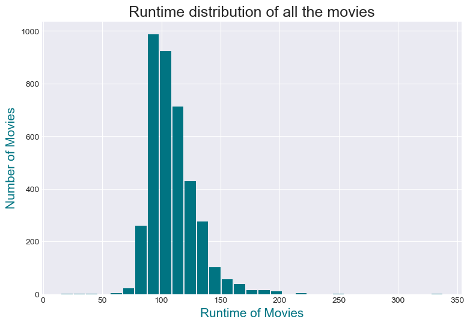

```python
#plotting a histogram of runtime of movies

#gives styles to bg plot
sns.set_style('darkgrid')

#chaging the label size, this will change the size of all plots that we plot from now!
plt.rc('xtick', labelsize = 10)
plt.rc('ytick', labelsize = 10)

#giving the figure size(width, height)
plt.figure(figsize=(9,6), dpi = 100)
#x-axis label name
plt.xlabel('Runtime of Movies', color = '#007482', fontsize = 15)
#y-axis label name
plt.ylabel('Number of Movies', color = '#007482', fontsize=15)
#title of the graph
plt.title('Runtime distribution of all the movies', fontsize=18)

#giving a histogram plot
plt.hist(movies_data['runtime'], rwidth = 0.9, bins =31, color = '#007482')
#displays the plot
plt.show()
```

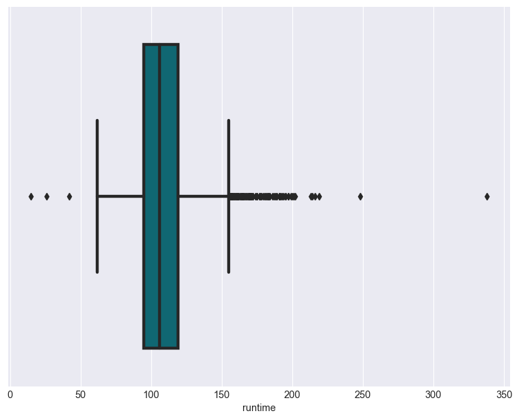

```python
#giving two plots, thr first is the box plot, second is plots of runtime for movies
#giving figure size
plt.figure(figsize=(9,7), dpi = 105)

#using seaborn to plot
#plotting box plot
sns.boxplot(movies_data['runtime'], linewidth = 3, color = '#007482')
#showing the plot
plt.show()
```

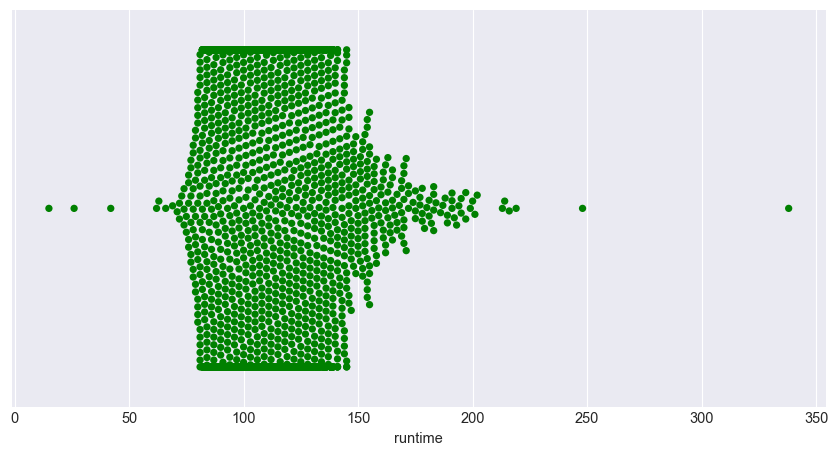

```python
#plots the data points of runtime of movies

#giving figure size
plt.figure(figsize=(10,5), dpi = 105)

sns.swarmplot(movies_data['runtime'], color = 'green')
plt.show()
```

```python
#getting specific runtime points at x positions
movies_data['runtime'].describe()
```

```
count    3854.000000
mean      109.220291
std        19.922820
min        15.000000
25%        95.000000
50%       106.000000
75%       119.000000
max       338.000000
Name: runtime, dtype: float64
```

As we can see there are more movies after the 3rd quartile range than the 1st. This makes the mean of the runtime pull towards the right or increases it.

### 1E

#### Average Budget of Movies

```python
#calling the function
prof_avg_fuc('budget_(in_NGN_Naira)')
```

```
57308877.08305425
```

The average budget made of movies was about -N-57M

### 1F

#### Average Revenue of Movies

```python
#calling the function
prof_avg_fuc('revenue_(in_NGN_Naira)')
```

```
236306323.37374413
```

The average revenue of movies of movies was around `-N-236M`.

### 1G

#### Which director directed most movies?

```python
#this will variable will store the return value from a function
director_count = extract_data('director')
#showing top 5 values
director_count.head()
```

```
Steven Spielberg    24
Clint Eastwood      15
Robert Zemeckis     13
Tim Burton          12
Ridley Scott        12
dtype: int64
```

Steven Spielberg directed the most numbers of movies within th period

### 1G

#### Which Genre was the most successful?

```python
#this will variable will store the return value from a function
genre_count = extract_data('genres')
#shwoing top 5 values
genre_count.head()
```

```
Drama        554
Comedy       542
Action       505
Thriller     454
Adventure    402
dtype: int64
```

**Visualizing within a plot.**

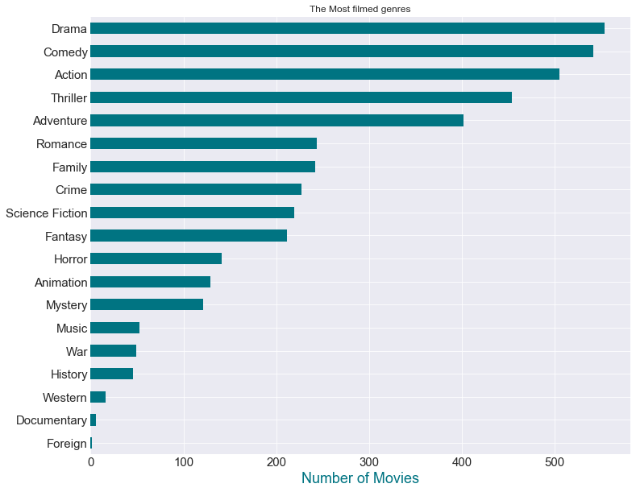

```python
#we want plot to plot points in descending order top to bottom
#since our count is in descending order and graph plot points from bottom to top, our graph will be in ascending order form top to bottom
#hence lets give the series in ascending order
genre_count.sort_values(ascending = True, inplace = True)

#initializing plot
ax = genre_count.plot.barh(color = '#007482', fontsize = 15)

#giving a title
ax.set(title = 'The Most filmed genres')

#x-label
ax.set_xlabel('Number of Movies', color = '#007482', fontsize = '18')

#giving the figure size(width, height)
ax.figure.set_size_inches(12, 10)

#shwoing the plot
plt.show()
```

Drama seemed to be the most popular with a grossing number of 500movies